# Classification for Credit Card Default

*Binkai Tan*

## 0. Brief introduction

### Context

The *CreditDefault* data set contains 800 samples, with 4 variables:  
1 dependent variable: *default* 3 independent variables: *balance*, *income*, *student*

| Name | Description |
| --- | --- |
| default | A binary factor containing whether or not a given user has defaulted on his/her credit card. (1=Defaulted, 0=Not Defaulted) |
| balance | The total credit card balance for a given credit card holder. |
| income | The gross annual income for a given credit card holder. |
| student | A binary factor containing whether or not a given credit card holder is a student. (Yes or No) |

The aim is to choose a set of suitable predictors and choose an optimal model for classifying the data set.

### Overview of my work

Based on the *CreditDefault* data set, we are supposed to find out an optimal model to classify the customers’ default status and predict it. During the process, I firstly loaded the data set and split it into training and test data sets, using graphs to explore the variables which may be suitable for predicting. Then, I performed a Logistic Regression based on the balance and calculated the misclassification rate as the indicator of model performance. Furthermore, I wrote a function manually performing LOOCV, on which I applied a bootstrap analysis. By using the bootstrap analysis, I test the performance of alternative predictor subsets, and finally chose an optimal model for classifying the data set. After examining the model, I put forward a method for bank to reduce the fraction of customers who default by 50%.

## 1. - Load in the Credit Card Default dataset provided and split the data into 50:50 training and test datasets.

1). Load the Credit Card Default data set and set the seed as 1.

```r
load("CreditDefault.RData")
set.seed(1)
```

2). Add a column for default_status as factor to draw plot.  
3). Change row names in ascending order.  
4). Split the data set into 2 part randomly: training data and test data, both of which have 400 samples. Here I used sample() function to get the rows in random. 5). Change the both row names in ascending order again. 6). Show the first six sample of the *CreditDefault*.

```r
CreditDefault$default_status <- as.factor(CreditDefault$default)
CreditDefault$student <- as.integer(CreditDefault$student)
rownames(CreditDefault) <- c(1 : nrow(CreditDefault))

n_training = nrow(CreditDefault)*0.5
training_rows=sample(1:nrow(CreditDefault),n_training)
CreditDefault.training <- CreditDefault[training_rows,]

CreditDefault.test <- CreditDefault[-training_rows,]
rownames(CreditDefault.training) <- c(1:nrow(CreditDefault.training))
rownames(CreditDefault.test) <- c(1:nrow(CreditDefault.test))

head(CreditDefault)
```

```
##   default    income   balance student default_status
## 1       0 16407.003  547.1977       2              0
## 2       1 42308.954 3142.6722       1              1
## 3       0 22992.186  475.6472       2              0
## 4       0  3998.925  637.6313       1              0
## 5       1 34362.635 1887.1718       1              1
## 6       1 44607.429  953.6125       1              1
```

## 2. - Explore the training data to investigate which variables may be suitable for predicting which customers will default on their loan, using suitable figures to illustrate your discussion.

1). Firstly, draw an income ~ balance scatter plot, where I use the red/black color to mark the default_status(red represents for Default, black represents for Not Default), and the shape of points to mark the Student_status(triangle represents for Student, circle represents for Non-Student).

[figure not shown]

```r
plot(income ~ balance, data = CreditDefault, col = default_status, pch = student, main = "Income ~ Balance \n red: Default; black: Not Default  circle: Student; triangle: Not Student")
```

2). Secondly, draw the box plot showing the relationship between balance and default_status. As it performs, “Non-default”" customers are seemingly get lower balance in their credit card, which is concentrated on 500 to 600. On the opposite, the customers who default on their credit card, own more balance around 1500. At the same time, customers who get a much higher balance are tend to default on their credit card. As a consequence, it is clear that the “default_status” has a related relationship with customers’ “balance”.

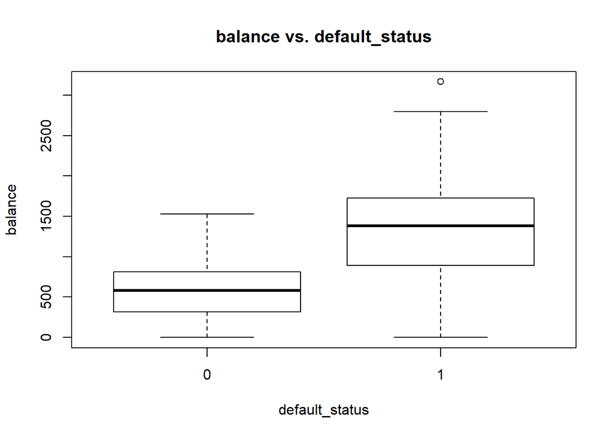

```r
plot(balance ~ default_status, data = CreditDefault.training, main="balance vs. default_status")
```

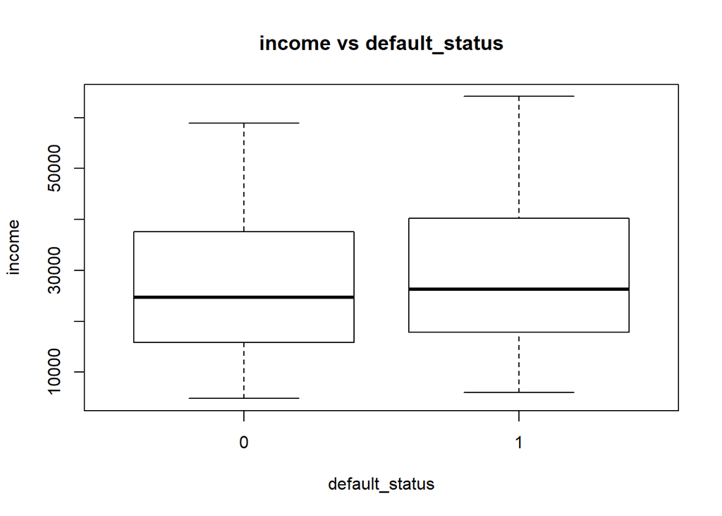

```r
plot(income ~ default_status, data = CreditDefault.training, main = "income vs default_status")
```

4). A frequency hist showing the distribution of balance under different default_status.

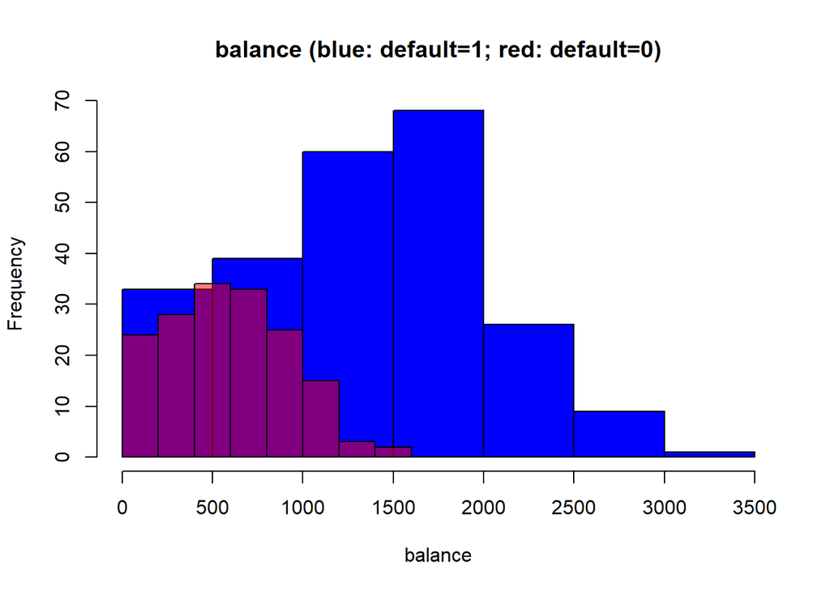

```r
hist(subset(CreditDefault.training, default==1)$balance, col='blue',
     xlab='balance',main='balance (blue: default=1; red: default=0)')
hist(subset(CreditDefault.training, default==0)$balance, col=rgb(1,0,0,0.5), add=T)
```

As is shown above, when the balance is below 1000 approximately, there is almost no difference between whether or not the default status is 1 or 0. However, as the balance goes higher, more customers get prone to default on their credit card. When the balance exceeds 1500, almost every customer default, which also manifests there is a relationship between “default” and “balance”.

5). Set up the glm model between default and balance, plot it and add a smooth curve. This graph indicates that there is a positive relationship between both variables.

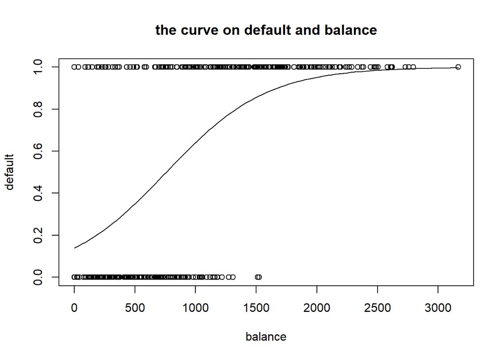

```r
default_balance.glm=glm(default ~ balance, data=CreditDefault.training, family=binomial)
plot(default ~ balance, data=CreditDefault.training, main = "the curve on default and balance")
curve(predict(default_balance.glm, data.frame(balance=x),type="resp"),add=TRUE)
```

## 3. - Perform a Logistic Regression fit to predict the probability of a customer defaulting based on their balance and display the fit.

```r
# logistic regression model
glm.balance <- glm(default~balance, family = "binomial", data = CreditDefault.training)
anova(glm.balance, test = "Chisq")
```

```
## Analysis of Deviance Table
##
## Model: binomial, link: logit
##
## Response: default
##
## Terms added sequentially (first to last)
##
##
##         Df Deviance Resid. Df Resid. Dev  Pr(>Chi)
## NULL                      399     541.49
## balance  1   140.23       398     401.25 < 2.2e-16 ***
## ---
## Signif. codes:  0 '***' 0.001 '**' 0.01 '*' 0.05 '.' 0.1 ' ' 1
```

```r
summary(glm.balance)
```

```
##
## Call:
## glm(formula = default ~ balance, family = "binomial", data = CreditDefault.training)
##
## Deviance Residuals:
##     Min       1Q   Median       3Q      Max
## -1.9976  -0.8945   0.3136   0.7475   1.9872
##
## Coefficients:
##               Estimate Std. Error z value Pr(>|z|)
## (Intercept) -1.8249573  0.2455496  -7.432 1.07e-13 ***
## balance      0.0024078  0.0002589   9.300  < 2e-16 ***
## ---
## Signif. codes:  0 '***' 0.001 '**' 0.01 '*' 0.05 '.' 0.1 ' ' 1
##
## (Dispersion parameter for binomial family taken to be 1)
##
##     Null deviance: 541.49  on 399  degrees of freedom
## Residual deviance: 401.25  on 398  degrees of freedom
## AIC: 405.25
##
## Number of Fisher Scoring iterations: 5
```

```r
# training data
CreditDefault.training$fitvalue <- predict(glm.balance, family = binomial, type = "resp")
CreditDefault.training$prediction <- rep(0, nrow(CreditDefault.training))
CreditDefault.training[which(CreditDefault.training$fitvalue >= 0.5), 7] <- 1
default.training.probability <- mean(CreditDefault.training$prediction)
cat("default probability(training data): ", default.training.probability)
```

```
## default probability(training data):  0.595
```

```r
head(CreditDefault.training)
```

```
##   default    income   balance student default_status  fitvalue prediction
## 1       0  7010.955  691.9584       2              0 0.4603614          0
## 2       0 41972.886  556.4746       1              0 0.3810485          0
## 3       0 18316.125  708.4080       2              0 0.4702150          0
## 4       0 23697.532  214.8746       1              0 0.2128903          0
## 5       0 19728.151  827.6825       2              0 0.5418774          1
## 6       1 18944.808 2196.5338       1              1 0.9696391          1
```

```r
# test data
CreditDefault.test$fitvalue <- predict(glm.balance, newdata = CreditDefault.test, family = binomial, type = "resp")
CreditDefault.test$prediction <- rep(0, nrow(CreditDefault.test))
CreditDefault.test[which(CreditDefault.test$fitvalue >= 0.5), 7] <- 1
default.test.probability <- mean(CreditDefault.test$prediction)
default.test.probability
```

```
## [1] 0.55
```

```r
cat("default probability(test data): ", default.test.probability)
```

```
## default probability(test data):  0.55
```

```r
head(CreditDefault.test)
```

```
##   default    income   balance student default_status  fitvalue prediction
## 1       0 16407.003  547.1977       2              0 0.3757946          0
## 2       1 42308.954 3142.6722       1              1 0.9968014          1
## 3       0 22992.186  475.6472       2              0 0.3363253          0
## 4       0  3998.925  637.6313       1              0 0.4280786          0
## 5       1 34362.635 1887.1718       1              1 0.9381326          1
## 6       1 44607.429  953.6125       1              1 0.6156470          1
```

## 4. - Calculate the misclassification rate for predicting customers who will default. We will use this measure as our indicator of model performance.

```r
# training data
prediction_0 <- rep(0, 2)
prediction_1 <- rep(0, 2)
result_table <- data.frame(prediction_0, prediction_1)
row.names(result_table) <- c("default_0", "default_1")

total.training <- nrow(CreditDefault.training)
misclassified.training <- length(which(CreditDefault.training$default != CreditDefault.training$prediction))
rate.training <- misclassified.training / total.training
cat("The misclassification rate is : ", rate.training)
```

```
## The misclassification rate is :  0.25
```

```r
for (i in c(0 : 1))
{
  subset <- CreditDefault.training[which(CreditDefault.training$prediction == i), ]
  for (j in c(0 : 1))
  {
    result_table[i+1, j+1] <- length(subset[which(subset$default == j), 1])
  }
}
result_table
```

```
##           prediction_0 prediction_1
## default_0          113           49
## default_1           51          187
```

2). Do the same operation to the test data.

```r
# test data
total.test <- nrow(CreditDefault.test)
misclassified.test <- length(which(CreditDefault.test$default != CreditDefault.test$prediction))
rate.test<- misclassified.test / total.test
rate.test
```

```
## [1] 0.2625
```

## 5. - Write a function that manually performs LOOCV to find an unbiased estimate for misclassification rate on our training data, and comment on the result.

1). This function will calculate LOOCV using all columns passed to it. This means we can use it with different models. Use it with a cut down copy of the data frame that just contains the response (default) and the columns to fit.

```r
loocv_mc <- function(dataset)
{
  n <- nrow(dataset)
  loocv_prediction <- rep(0, n)

  for(i in 1:n){
    # make a data frame containing all rows except row "i"
    dataset.loocv <- dataset[-i, ]

    # and perform the fit on this training data
    glm.fit <- glm(default ~ ., data=dataset.loocv, family=binomial)

    # we then use this fit to predict the remaining point
    # that was not used in the fit.
    predict_for_row <- predict(glm.fit, newdata=dataset[i,])

    # if predict_for_row < 0.5 predict 0, else predict 1
    # and store the predictions in our vector
    if (predict_for_row >= 0.5)
      loocv_prediction[i] <- 1
  }

  # loocv_prediction now has a list of all predictions
  # calculate the misclassification from this and out dataset
  misclassified <- length(which(dataset$default != loocv_prediction))
  rate <- misclassified/n
  return (rate)
}
```

2). To call to test on default ~ balance

```r
CreditDefault.balance <- CreditDefault[,c('default','balance')]
loocv_mc(CreditDefault.balance)
```

```
## [1] 0.23875
```

## 6. - Write a for loop to apply a bootstrap analysis on the LOOCV misclassification rate. This will first generate a bootstrapped dataset using the training data, then calculate the associated LOOCV value using your function. Use the results to explore the generated distribution for misclassification rate.

1). Run the bootstrap analysis for 10 times, re-sampling the rows of data set with replacement. Calculate the mean and error value of the misclassified results, and return them.

```r
run_bootstrap_10 <- function(dataset){
  # runs bootstrap analysis 10 times
  loocv_results <- rep(0,10)
  for (i in 1:10){
    n <- nrow(dataset)
    resampled_rows <- sample(1:n, n, replace = TRUE)
    dataset.bootstrapped <- dataset[resampled_rows, ]

    loocv_results[i] <- loocv_mc(dataset.bootstrapped)
  }

  mean_misclassify <- mean(loocv_results)
  error_misclassify <- sd(loocv_results) / sqrt(10)
  result <- c(mean_misclassify, error_misclassify)
  return(result)
}
# this function finds the loocv misclassification rate for 10 bootstrapped distributions
# it will fit using all predictor columns
```

2). Test the function with the parameters beneath.

```r
CreditDefault.balance <- CreditDefault.training[, c("default", "balance")]
CreditDefault.balance_income <- CreditDefault.training[, c("default", "balance", "income")]
CreditDefault.balance_income_student <- CreditDefault.training[, c("default", "balance", "income", "student")]
# e.g. create the following data frames with different predictor sets
run_bootstrap_10(CreditDefault.balance)
```

```
## [1] 0.222000000 0.009991663
```

```r
run_bootstrap_10(CreditDefault.balance_income)
```

```
## [1] 0.198250000 0.003436932
```

```r
run_bootstrap_10(CreditDefault.balance_income_student)
```

```
## [1] 0.213000000 0.005201496
```

## 7. - The code you have written forms a method for testing model performance and cross validating the performance measurement. Use this to explore manually test the performance of alternative predictor subsets, and choose an optimal model for classifying this dataset.

1). Create a table to perform the mean and error value of misclassified results in the seven models beneath:  
default ~ balance; default ~ income; default ~ student; default ~ balance + income; default ~ balance + student; default ~ income + student; default ~ balance + income + student

```r
mean_misclassify <- rep(0, 7)
error_misclassify <- rep(0, 7)
result <- data.frame(mean_misclassify, error_misclassify)
row.names(result) <- c("balance", "income", "student", "balance_income", "balance_student", "income_student", "balance_income_student")
```

2). Create the seven models to traverse all the possibilities to find the optimized one.

```r
CreditDefault.balance <- CreditDefault.training[, c("default", "balance")]
CreditDefault.income <- CreditDefault.training[, c("default", "income")]
CreditDefault.student <- CreditDefault.training[, c("default", "student")]
CreditDefault.balance_income <- CreditDefault.training[, c("default", "balance", "income")]
CreditDefault.balance_student <- CreditDefault.training[, c("default", "balance", "student")]
CreditDefault.income_student <- CreditDefault.training[, c("default", "income", "student")]
CreditDefault.balance_income_student <- CreditDefault.training[, c("default", "balance", "income", "student")]
```

3). Create the following data frames with different predictor sets.

```r
result[1, ] = run_bootstrap_10(CreditDefault.balance)
result[2, ] = run_bootstrap_10(CreditDefault.income)
result[3, ] = run_bootstrap_10(CreditDefault.student)
result[4, ] = run_bootstrap_10(CreditDefault.balance_income)
result[5, ] = run_bootstrap_10(CreditDefault.balance_student)
result[6, ] = run_bootstrap_10(CreditDefault.income_student)
result[7, ] = run_bootstrap_10(CreditDefault.balance_income_student)
```

4). Create one column to record the max of each model’s misclassified results. max = mean + sd/sqrt(10) = mean_misclassified + error_misclassified. To find out the optimized model, we are supposed to choose the smallest one.

```r
result$max<-round(result$mean_misclassify+result$error_misclassify, 3)
result
```

```
##                        mean_misclassify error_misclassify   max
## balance                         0.21925       0.007265310 0.227
## income                          0.52575       0.011571337 0.537
## student                         0.33900       0.005988415 0.345
## balance_income                  0.21975       0.005645180 0.225
## balance_student                 0.19150       0.006023104 0.198
## income_student                  0.37350       0.025161147 0.399
## balance_income_student          0.22000       0.008308296 0.228
```

As is indicated above, the lowest max_value of misclassification is 0.198 as “balance_student”. As a result, we choose balance and student as our optimized predictors.

## 8. - Examine the performance of the model on the test dataset, and comment on your result.

1). Using “balance” and “student” as independent variables. We can get the regression function.

```r
glm.balance_student <- glm(default ~ balance + student, data = CreditDefault.training)
summary(glm.balance_student)
```

```
##
## Call:
## glm(formula = default ~ balance + student, data = CreditDefault.training)
##
## Deviance Residuals:
##      Min        1Q    Median        3Q       Max
## -0.73072  -0.34734  -0.01377   0.32330   0.95744
##
## Coefficients:
##               Estimate Std. Error t value Pr(>|t|)
## (Intercept)  5.151e-01  6.939e-02   7.422 7.07e-13 ***
## balance      3.886e-04  2.988e-05  13.004  < 2e-16 ***
## student     -2.584e-01  4.684e-02  -5.516 6.26e-08 ***
## ---
## Signif. codes:  0 '***' 0.001 '**' 0.01 '*' 0.05 '.' 0.1 ' ' 1
##
## (Dispersion parameter for gaussian family taken to be 0.1610861)
##
##     Null deviance: 96.760  on 399  degrees of freedom
## Residual deviance: 63.951  on 397  degrees of freedom
## AIC: 409.81
##
## Number of Fisher Scoring iterations: 2
```

```r
b0 <- glm.balance_student$coefficients[["(Intercept)"]]
b1 <- glm.balance_student$coefficients[["balance"]]
b2 <- glm.balance_student$coefficients[["student"]]
cat("The regrssion function is : default = ", b0, "+", b1, "*balance", b2, "*student","\n")
```

```
## The regrssion function is : default =  0.5150741 + 0.0003885597 *balance -0.2583768 *student
```

As is shown above, the model passed the t-test and F-test which are significant. The AIC is 409.81. The regrssion function is : default = 0.5150741 + 0.0003885597 balance -0.2583768 student

2). The misclassification rate is 0.245.

```r
CreditDefault.test$fitvalue <- predict(glm.balance_student, newdata = CreditDefault.test)
CreditDefault.test$prediction <- rep(0, nrow(CreditDefault.test))
CreditDefault.test[which(CreditDefault.test$fitvalue >= 0.5), 7] <- 1

total.test <- nrow(CreditDefault.test)
misclassified.test <- length(which(CreditDefault.test$default != CreditDefault.test$prediction))
rate.test<- misclassified.test / total.test
rate.test
```

```
## [1] 0.245
```

## 9. - The bank wants to use the analysis to reduce the fraction of customers who default by 50%. Describe how they could use your model to do this.

```r
# student = 2 represents the customer is a student. student = 1 represents the customer is not a student.
CreditDefault.training$student <- as.integer(CreditDefault.training$student)
CreditDefault.test$student <- as.integer(CreditDefault.test$student)

temp_isStudent <- predict(glm.balance_student, newdata = subset(subset(CreditDefault.training, default == 1), student == 2), family=binomial, type = "resp")
cat("Threshold_is_Student: ", median(temp_isStudent), "\n")
```

```
## Threshold_is_Student:  0.5407438
```

```r
length_delete <- length(subset(subset(CreditDefault.test, default == 1), student == 2)[which(predict(glm.balance_student, newdata = subset(subset(CreditDefault.test, default == 1), student == 2), family=binomial, type = "resp") > median(temp_isStudent)), 1])
cat("Number of customers who exceeds the threshold (default=1, student=Yes): ", length_delete, "\n")
```

```
## Number of customers who exceeds the threshold (default=1, student=Yes):  13
```

```r
length_total <- length(subset(subset(CreditDefault.test, default == 1), student == 2)[, 1])
cat("Number of customers (default=1, student=Yes)", length_total, "\n")
```

```
## Number of customers (default=1, student=Yes) 30
```

2). Then we test customers who are not students. It shows 85 out of 197 (43.15%) non-student customers defaulting on credit card have been reduced.

```r
temp_notStudent <- predict(glm.balance_student, newdata = subset(subset(CreditDefault.training, default == 1), student == 1), family=binomial, type = "resp")
cat("Threshold_not_Student: ", median(temp_notStudent), "\n")
```

```
## Threshold_not_Student:  0.7888923
```

```r
length_delete <- length(subset(subset(CreditDefault.test, default == 1), student == 2)[which(predict(glm.balance_student, newdata = subset(subset(CreditDefault.test, default == 1), student == 1), family=binomial, type = "resp") > median(temp_notStudent)), 1])
cat("Number of customers who exceeds the threshold (default=1, student=No): ", length_delete, "\n")
```

```
## Number of customers who exceeds the threshold (default=1, student=No):  85
```

```r
length_total <- length(subset(subset(CreditDefault.test, default == 1), student == 1)[, 1])
cat("Number of customers (default=1, student=No)", length_total, "\n")
```

```
## Number of customers (default=1, student=No) 197
```

3). Using the regression function to calculate the threshold of balance corresponding to the default threshold above.

```r
cat("The regrssion function is : default = ", b0, "+", b1, "*balance", b2, "*student","\n")
```

```
## The regrssion function is : default =  0.5150741 + 0.0003885597 *balance -0.2583768 *student
```

```r
Threshold_Balance_isStudent <- (median(temp_isStudent) - b0- 2*b2) / b1
Threshold_Balance_notStudent <- (median(temp_notStudent) - b0- 2*b2) / b1
cat("The threshold of balance for students is : ", Threshold_Balance_isStudent, "\n")
```

```
## The threshold of balance for students is :  1395.984
```

```r
cat("The threshold of balance for customers who are not students is : ", Threshold_Balance_notStudent, "\n")
```

```
## The threshold of balance for customers who are not students is :  2034.621
```

As a result, the suggestion for the bank is to check the balance of it’s customers and compare it with the corresponding threshold.

```r
CreditDefault$default_status <- as.factor(CreditDefault$default)
CreditDefault$student <- as.integer(CreditDefault$student)
rownames(CreditDefault) <- c(1 : nrow(CreditDefault))

n_test = nrow(CreditDefault)*0.8
test_rows=sample(1:nrow(CreditDefault),n_test)
CreditDefault.bank.test <- CreditDefault[test_rows,]

CreditDefault.training$student <- as.integer(CreditDefault.training$student)
CreditDefault.test$student <- as.integer(CreditDefault.test$student)
subset(subset(CreditDefault.bank.test, default == 1), student == 2)$balance > Threshold_Balance_isStudent
```

```
##  [1] FALSE FALSE FALSE FALSE  TRUE FALSE FALSE FALSE FALSE FALSE FALSE
## [12] FALSE  TRUE  TRUE FALSE  TRUE  TRUE  TRUE FALSE  TRUE  TRUE FALSE
## [23]  TRUE FALSE FALSE FALSE  TRUE FALSE FALSE FALSE  TRUE FALSE  TRUE
## [34]  TRUE FALSE  TRUE FALSE FALSE  TRUE FALSE  TRUE  TRUE  TRUE  TRUE
## [45] FALSE FALSE FALSE  TRUE FALSE FALSE
```

```r
length_bank_delete <- length(which(subset(subset(CreditDefault.bank.test, default == 1), student == 2)$balance > Threshold_Balance_isStudent))
length_bank_delete
```

```
## [1] 20
```

```r
length_bank <- length(subset(subset(CreditDefault.bank.test, default == 1), student == 2)[,1])
length_bank
```

```
## [1] 50
```

```r
cat("The reduce rate of student customers:", length_bank_delete/length_bank)
```

```
## The reduce rate of student customers: 0.4
```

## 10. Summary

A huge THANK for the help of Professor Lewis! This report contains various of methods to analysis the data set and finally puts forward a suggestion on whether to give credit card to customers for the bank. During the process, I have practiced a lot not only on dealing with data in R, but also on the logical and statistical thinking.